# Introduction to metafrontier

## What is a metafrontier?

In efficiency analysis, we often study firms that operate under different production environments. Steel producers using electric arc furnaces (EAF) face a different feasible set of input-output combinations than those using the blast furnace-basic oxygen furnace (BF-BOF) route. Hospitals in rural areas face different constraints than urban ones. Banks face different regulatory environments across jurisdictions.

Following Battese, Rao, and O’Donnell (2004) and O’Donnell, Rao, and Battese (2008), we conceive of a single industry **metatechnology** $T^*$: the set of all input-output combinations that are technically feasible in the industry. Each group of firms operates within a **restricted subset** $T_j \subseteq T^*$ of this metatechnology, where the restrictions arise from regulation, the physical environment, resource endowments, or the cost of switching production systems. Groups do not possess fundamentally different technologies; they face different restrictions of a common metatechnology.

Standard stochastic frontier analysis (SFA) or data envelopment analysis (DEA) applied to the pooled sample implicitly assumes that all firms have unrestricted access to the same technology set, an assumption that may be unrealistic. Estimating separate frontiers for each group solves this problem but makes efficiency scores incomparable across groups: a firm that is 90% efficient relative to a less advanced group frontier may actually be less productive than a firm that is 70% efficient relative to a more advanced frontier.

The **metafrontier** framework, introduced by Battese, Rao, and O’Donnell (2004) and extended by Huang, Huang, and Liu (2014) and O’Donnell, Rao, and Battese (2008), resolves this by:

1. Estimating **group-specific frontiers** for each technology group
2. Estimating a **metafrontier** that envelops all group frontiers
3. Decomposing efficiency into two components:

$$TE^*_i = TE_i \times TGR_i$$

where:

- $TE_i$ is efficiency relative to the **group frontier** (within-group inefficiency)
- $TGR_i$ is the **technology gap ratio**, measuring how close the group frontier is to the metafrontier (between-group technology gap)
- $TE^*_i$ is efficiency relative to the **metafrontier** (overall efficiency)

The `metafrontier` package provides a unified interface for estimating metafrontier models using both SFA and DEA approaches.

## Quick start

```r
library(metafrontier)
```

### Simulate data

The package includes `simulate_metafrontier()` for generating data from a known data-generating process. This is useful for Monte Carlo studies and for learning the package.

```r
sim <- simulate_metafrontier(
  n_groups = 3,
  n_per_group = 200,
  beta_meta = c(1.0, 0.5, 0.3),  # intercept, elasticity_1, elasticity_2
  tech_gap = c(0, 0.25, 0.5),    # intercept shifts (0 = best technology)
  sigma_u = c(0.2, 0.3, 0.4),    # inefficiency SD per group
  sigma_v = 0.15,                 # noise SD
  seed = 42
)

str(sim$data[, c("log_y", "log_x1", "log_x2", "group")])
```

```
#> 'data.frame':    600 obs. of  4 variables:
#>  $ log_y : num  4.05 3.99 3.16 4.04 2.52 ...
#>  $ log_x1: num  4.57 4.69 1.43 4.15 3.21 ...
#>  $ log_x2: num  4.426 2.586 4.26 2.214 0.789 ...
#>  $ group : Factor w/ 3 levels "G1","G2","G3": 1 1 1 1 1 1 1 1 1 1 ...
```

```r
table(sim$data$group)
```

```
#>
#>  G1  G2  G3
#> 200 200 200
```

The simulation generates a Cobb-Douglas frontier:
$$\ln y_i = \beta_0^{(j)} + \beta_1 \ln x_{1i} +
\beta_2 \ln x_{2i} + v_i - u_i$$
where the intercept $\beta_0^{(j)} = \beta_0^* - \delta_j$ is shifted down from the metafrontier by the technology gap $\delta_j$ for group $j$.

### Estimate the metafrontier

```r
fit <- metafrontier(
  log_y ~ log_x1 + log_x2,
  data = sim$data,
  group = "group",
  method = "sfa",
  meta_type = "deterministic"
)

fit
```

```
#>
#> Metafrontier Model
#> ------------------
#> Method:           sfa
#> Metafrontier:     deterministic
#> Frontier:         production
#> Estimator:        bc88
#> Objective:        lp
#> Groups:           G1, G2, G3
#> Total obs:        600
#>   G1: 200 obs
#>   G2: 200 obs
#>   G3: 200 obs
#>
#> Group log-likelihoods:
#>   G1: 35.49
#>   G2: 0.84652
#>   G3: -25.399
#>
#> Mean TGR by group:
#>   G1: 1
#>   G2: 0.7593
#>   G3: 0.6047
#>
#> Convergence: OK
```

## Deterministic SFA metafrontier (Battese, Rao, and O’Donnell, 2004)

The deterministic metafrontier is estimated in two stages:

1. **Stage 1**: Fit separate SFA models for each group via maximum likelihood.
2. **Stage 2**: Find metafrontier coefficients $\hat\beta^*$ by minimising
   $$\sum_i \left|\ln f(x_i; \hat\beta^*) - \ln f(x_i;
   \hat\beta_j)\right|$$
   subject to the constraint that the metafrontier envelops all group frontiers: $\ln f(x_i; \hat\beta^*) \ge \ln f(x_i; \hat\beta_j)$ for all $i$ and $j$. Since the envelopment constraints force the deviations to be non-negative, this reduces to a linear programme (`objective = "lp"`, the default). The alternative minimum sum of squared deviations criterion is available via `objective = "qp"`; both criteria are proposed by Battese, Rao, and O’Donnell (2004), and the `methods` vignette discusses them in detail.

This is the default method:

```r
fit_det <- metafrontier(
  log_y ~ log_x1 + log_x2,
  data = sim$data,
  group = "group",
  meta_type = "deterministic"
)

summary(fit_det)
```

```
#>
#> Metafrontier Model Summary
#> ==========================
#>
#> Call:
#> metafrontier(formula = log_y ~ log_x1 + log_x2, data = sim$data,
#>     group = "group", meta_type = "deterministic")
#>
#> Method:        sfa
#> Metafrontier:  deterministic
#> Frontier:      production
#>
#> --- Group: G1 (n = 200) ---
#>              Estimate Std. Error z value Pr(>|z|)
#> (Intercept)  1.025588   0.060881  16.846  < 2e-16 ***
#> log_x1       0.493508   0.009658  51.097  < 2e-16 ***
#> log_x2       0.294569   0.009805  30.042  < 2e-16 ***
#> log_sigma_v -1.800325   0.155456 -11.581  < 2e-16 ***
#> log_sigma_u -1.627386   0.313233  -5.195 2.04e-07 ***
#> ---
#> Signif. codes:  0 '***' 0.001 '**' 0.01 '*' 0.05 '.' 0.1 ' ' 1
#> Log-likelihood: 35.49
#>
#> --- Group: G2 (n = 200) ---
#>             Estimate Std. Error z value Pr(>|z|)
#> (Intercept)  0.76703    0.06478   11.84  < 2e-16 ***
#> log_x1       0.48428    0.01239   39.10  < 2e-16 ***
#> log_x2       0.29703    0.01210   24.55  < 2e-16 ***
#> log_sigma_v -1.65583    0.16136  -10.26  < 2e-16 ***
#> log_sigma_u -1.39987    0.28108   -4.98 6.35e-07 ***
#> ---
#> Signif. codes:  0 '***' 0.001 '**' 0.01 '*' 0.05 '.' 0.1 ' ' 1
#> Log-likelihood: 0.84652
#>
#> --- Group: G3 (n = 200) ---
#>             Estimate Std. Error z value Pr(>|z|)
#> (Intercept)  0.53665    0.05513   9.734   <2e-16 ***
#> log_x1       0.49950    0.01238  40.352   <2e-16 ***
#> log_x2       0.28205    0.01186  23.782   <2e-16 ***
#> log_sigma_v -1.94321    0.14404 -13.490   <2e-16 ***
```

[output cut: 10 more lines]

```
#>
#> --- Efficiency Decomposition ---
#>  Group Mean_TE Mean_TGR Mean_TE_star
#>     G1  0.8607   1.0000       0.8607
#>     G2  0.8300   0.7593       0.6302
#>     G3  0.7450   0.6047       0.4504
#>
#> --- Technology Gap Ratio Summary ---
#>  Group   N   Mean     SD    Min     Q1 Median     Q3    Max
#>     G1 200 1.0000 0.0000 1.0000 1.0000 1.0000 1.0000 1.0000
#>     G2 200 0.7593 0.0099 0.7386 0.7518 0.7592 0.7679 0.7799
#>     G3 200 0.6047 0.0125 0.5769 0.5947 0.6056 0.6143 0.6289
#>
#> --- Convergence ---
#> All estimation stages converged.
```

## Stochastic metafrontier (Huang, Huang, and Liu, 2014)

The stochastic metafrontier replaces the LP in Stage 2 with a second-stage SFA, using the fitted group frontier values as the dependent variable:

$$\ln \hat{f}(x_i; \hat\beta_j) =
x_i'\beta^* + v^*_i - u^*_i$$

where $u^*_i \ge 0$ captures the technology gap stochastically. This provides a distributional framework for the TGR, enabling standard errors and hypothesis testing.

```r
fit_sto <- metafrontier(
  log_y ~ log_x1 + log_x2,
  data = sim$data,
  group = "group",
  meta_type = "stochastic"
)

summary(fit_sto)
```

```
#>
#> Metafrontier Model Summary
#> ==========================
#>
#> Call:
#> metafrontier(formula = log_y ~ log_x1 + log_x2, data = sim$data,
#>     group = "group", meta_type = "stochastic")
#>
#> Method:        sfa
#> Metafrontier:  stochastic
#> Frontier:      production
#>
#> --- Group: G1 (n = 200) ---
#>              Estimate Std. Error z value Pr(>|z|)
#> (Intercept)  1.025588   0.060881  16.846  < 2e-16 ***
#> log_x1       0.493508   0.009658  51.097  < 2e-16 ***
#> log_x2       0.294569   0.009805  30.042  < 2e-16 ***
#> log_sigma_v -1.800325   0.155456 -11.581  < 2e-16 ***
#> log_sigma_u -1.627386   0.313233  -5.195 2.04e-07 ***
#> ---
#> Signif. codes:  0 '***' 0.001 '**' 0.01 '*' 0.05 '.' 0.1 ' ' 1
#> Log-likelihood: 35.49
#>
#> --- Group: G2 (n = 200) ---
#>             Estimate Std. Error z value Pr(>|z|)
#> (Intercept)  0.76703    0.06478   11.84  < 2e-16 ***
#> log_x1       0.48428    0.01239   39.10  < 2e-16 ***
#> log_x2       0.29703    0.01210   24.55  < 2e-16 ***
#> log_sigma_v -1.65583    0.16136  -10.26  < 2e-16 ***
#> log_sigma_u -1.39987    0.28108   -4.98 6.35e-07 ***
#> ---
#> Signif. codes:  0 '***' 0.001 '**' 0.01 '*' 0.05 '.' 0.1 ' ' 1
#> Log-likelihood: 0.84652
#>
#> --- Group: G3 (n = 200) ---
#>             Estimate Std. Error z value Pr(>|z|)
#> (Intercept)  0.53665    0.05513   9.734   <2e-16 ***
#> log_x1       0.49950    0.01238  40.352   <2e-16 ***
#> log_x2       0.28205    0.01186  23.782   <2e-16 ***
#> log_sigma_v -1.94321    0.14404 -13.490   <2e-16 ***
```

[output cut: 13 more lines]

```
#>
#> --- Efficiency Decomposition ---
#>  Group Mean_TE Mean_TGR Mean_TE_star
#>     G1  0.8607   0.9948       0.8563
#>     G2  0.8300   0.9947       0.8256
#>     G3  0.7450   0.9947       0.7410
#>
#> --- Technology Gap Ratio Summary ---
#>  Group   N   Mean SD    Min     Q1 Median     Q3    Max
#>     G1 200 0.9948  0 0.9948 0.9948 0.9948 0.9948 0.9949
#>     G2 200 0.9947  0 0.9947 0.9947 0.9947 0.9947 0.9948
#>     G3 200 0.9947  0 0.9946 0.9947 0.9947 0.9947 0.9947
#>
#> --- Convergence ---
#> All estimation stages converged.
```

The stochastic metafrontier provides a variance-covariance matrix:

```r
vcov(fit_sto)
```

```
#>               (Intercept)        log_x1        log_x2
#> (Intercept)  3.490785e-02 -8.889894e-05 -7.974475e-05
#> log_x1      -8.889894e-05  3.502404e-05 -4.372711e-07
#> log_x2      -7.974475e-05 -4.372711e-07  3.401693e-05
```

## DEA-based metafrontier

For a nonparametric approach, set `method = "dea"`:

```r
fit_dea <- metafrontier(
  log_y ~ log_x1 + log_x2,
  data = sim$data,
  group = "group",
  method = "dea",
  rts = "vrs"
)
fit_dea
```

```
#>
#> Metafrontier Model
#> ------------------
#> Method:           dea
#> Metafrontier:     deterministic
#> Groups:           G1, G2, G3
#> Total obs:        600
#>   G1: 200 obs
#>   G2: 200 obs
#>   G3: 200 obs
#>
#> Mean TGR by group:
#>   G1: 0.9959
#>   G2: 0.9221
#>   G3: NA
#>
#> Convergence: WARNING (group: G3, metafrontier)
```

The DEA metafrontier computes:

1. Group-specific DEA efficiencies under variable returns to scale (VRS), constant returns to scale (CRS), or other assumptions.
2. A pooled DEA across all observations to form the metafrontier.
3. $TGR_i = TE^{pool}_i / TE^{group}_i$.

## Extracting results

### Efficiency scores

Use `efficiencies()` to extract the three components of the decomposition:

```r
te <- efficiencies(fit_det, type = "group")
tgr <- efficiencies(fit_det, type = "tgr")
te_star <- efficiencies(fit_det, type = "meta")

# Verify the fundamental identity: TE* = TE x TGR
all.equal(te_star, te * tgr)
```

```
#> [1] TRUE
```

For SFA fits, technical efficiencies are computed with the Battese and Coelli (1988) conditional expectation estimator by default (`estimator = "bc88"`). The Jondrow et al. (1982) estimator is computed and stored alongside it, so you can switch without refitting:

```r
te_jlms <- efficiencies(fit_det, type = "group", estimator = "jlms")
cor(te, te_jlms)
```

```
#> [1] 0.9999314
```

### Technology gap ratio

The `technology_gap_ratio()` function returns TGR values grouped by technology:

```r
tgr_by_group <- technology_gap_ratio(fit_det)
lapply(tgr_by_group, summary)
```

```
#> $G1
#>    Min. 1st Qu.  Median    Mean 3rd Qu.    Max.
#>       1       1       1       1       1       1
#>
#> $G2
#>    Min. 1st Qu.  Median    Mean 3rd Qu.    Max.
#>  0.7386  0.7518  0.7592  0.7593  0.7679  0.7799
#>
#> $G3
#>    Min. 1st Qu.  Median    Mean 3rd Qu.    Max.
#>  0.5769  0.5947  0.6056  0.6047  0.6143  0.6289
```

For a formatted summary table:

```r
tgr_summary(fit_det)
```

```
#>   Group   N      Mean          SD       Min        Q1    Median        Q3
#> 1    G1 200 1.0000000 0.000000000 1.0000000 1.0000000 1.0000000 1.0000000
#> 2    G2 200 0.7592884 0.009947071 0.7385586 0.7517742 0.7592422 0.7679385
#> 3    G3 200 0.6047017 0.012456784 0.5769063 0.5947118 0.6056158 0.6142562
#>         Max
#> 1 1.0000000
#> 2 0.7798918
#> 3 0.6289392
```

### Coefficients

```r
# Metafrontier coefficients
coef(fit_det, which = "meta")
```

```
#> (Intercept)      log_x1      log_x2
#>   1.0255883   0.4935078   0.2945688
```

```r
# Group-specific coefficients
coef(fit_det, which = "group")
```

```
#> $G1
#> (Intercept)      log_x1      log_x2
#>   1.0255883   0.4935078   0.2945688
#>
#> $G2
#> (Intercept)      log_x1      log_x2
#>   0.7670252   0.4842818   0.2970328
#>
#> $G3
#> (Intercept)      log_x1      log_x2
#>   0.5366478   0.4994989   0.2820525
```

### Model information

```r
# Log-likelihood (sum of group log-likelihoods for deterministic)
logLik(fit_det)
```

```
#> 'log Lik.' 10.9376 (df=3)
```

```r
# Number of observations
nobs(fit_det)
```

```
#> [1] 600
```

```r
# AIC and BIC (available automatically via logLik method)
AIC(fit_det)
```

```
#> [1] -15.87521
```

## Visualisation

### TGR distributions

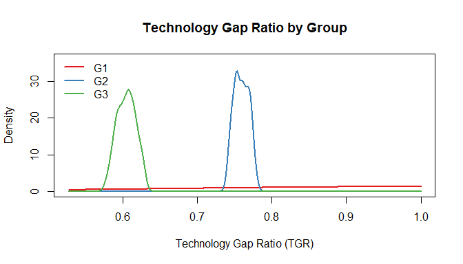

```r
plot(fit_det, which = "tgr")
```

### Efficiency scatter

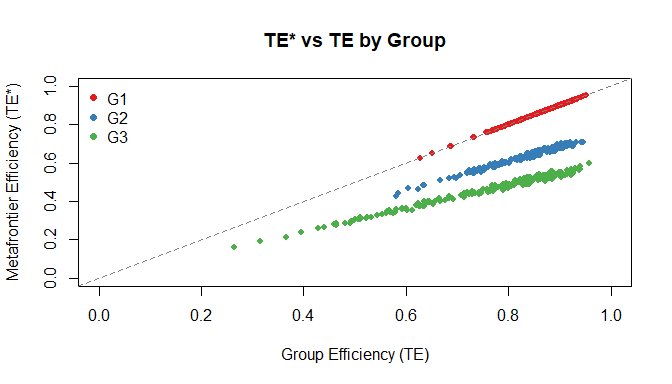

```r
plot(fit_det, which = "efficiency")
```

Points below the 45-degree line indicate a technology gap (TE* < TE). The vertical distance from the line reflects the TGR.

### Efficiency decomposition

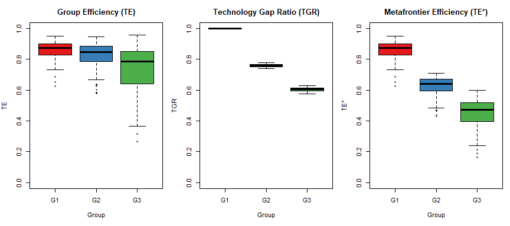

```r
plot(fit_det, which = "decomposition")
```

Side-by-side boxplots of TE, TGR, and TE* by group.

## Hypothesis testing

### Poolability test

The poolability test evaluates whether group-specific frontiers are statistically different from a single pooled frontier:

```r
poolability_test(fit_det)
```

```
#>
#>  Likelihood Ratio Test for Poolability of Group Frontiers
#>
#> data:  fit_det
#> LR = 504.71, df = 10, p-value < 2.2e-16
```

A significant result (small p-value) indicates that the group frontiers genuinely differ, that is, the groups face different restrictions of the common metatechnology, justifying the metafrontier approach.

### Convergence diagnostics

Every estimation stage of a metafrontier fit can be inspected with `check_convergence()`, which returns one row per stage (each group frontier and the metafrontier itself) with the estimation method, the optimiser’s convergence code, and a logical convergence indicator:

```r
check_convergence(fit_det)
```

```
#>
#> Convergence of estimation stages
#> --------------------------------
#>         stage method code converged note
#>     group: G1    MLE    0      TRUE
#>     group: G2    MLE    0      TRUE
#>     group: G3    MLE    0      TRUE
#>  metafrontier     LP    0      TRUE
```

The `summary()` method also prints a convergence block, so estimation problems are flagged even if you never call `check_convergence()` directly.

## Inefficiency distributions

The package supports three distributional assumptions for the one-sided inefficiency term $u_i$ in SFA:

```r
# Half-normal (default): u ~ |N(0, sigma_u^2)|
fit_hn <- metafrontier(log_y ~ log_x1 + log_x2,
                       data = sim$data, group = "group",
                       dist = "hnormal")

# Truncated normal: u ~ N+(mu, sigma_u^2)
fit_tn <- metafrontier(log_y ~ log_x1 + log_x2,
                       data = sim$data, group = "group",
                       dist = "tnormal")

# Exponential: u ~ Exp(1/sigma_u)
fit_exp <- metafrontier(log_y ~ log_x1 + log_x2,
                        data = sim$data, group = "group",
                        dist = "exponential")
```

## Comparing true and estimated values

Since we used simulated data, we can compare estimated values against the truth:

```r
# True vs estimated metafrontier coefficients
cbind(
  True = sim$params$beta_meta,
  Estimated = coef(fit_det, which = "meta")
)
```

```
#>             True Estimated
#> (Intercept)  1.0 1.0255883
#> log_x1       0.5 0.4935078
#> log_x2       0.3 0.2945688
```

```r
# True vs estimated mean TGR by group
true_tgr <- tapply(sim$data$true_tgr, sim$data$group, mean)
est_tgr <- tapply(fit_det$tgr, fit_det$group_vec, mean)
cbind(True = true_tgr, Estimated = est_tgr)
```

```
#>         True Estimated
#> G1 1.0000000 1.0000000
#> G2 0.7788008 0.7592884
#> G3 0.6065307 0.6047017
```

```r
# Correlation between true and estimated efficiency
cor(sim$data$true_te, fit_det$te_group)
```

```
#> [1] 0.8049637
```

```r
cor(sim$data$true_te_star, fit_det$te_meta)
```

```
#> [1] 0.9395109
```

## Panel SFA Metafrontier

The package supports panel data via the Battese-Coelli (1992) and (1995) models. Use the `panel` argument:

```r
# Simulate panel data
panel_sim <- simulate_panel_metafrontier(
  n_groups = 2, n_firms_per_group = 20, n_periods = 5, seed = 42
)

# BC92: time-varying inefficiency u_it = u_i * exp(-eta*(t-T))
fit_panel <- metafrontier(
  log_y ~ log_x1 + log_x2,
  data = panel_sim$data,
  group = "group",
  panel = list(id = "firm", time = "year"),
  panel_dist = "bc92"
)
summary(fit_panel)

# The eta parameter captures time-varying inefficiency
# eta > 0: inefficiency decreasing over time
# eta < 0: inefficiency increasing over time
```

## Bootstrap Confidence Intervals for TGR

The `boot_tgr()` function provides parametric and nonparametric bootstrap confidence intervals for the technology gap ratio. The nonparametric bootstrap resamples DMUs within each group, so a column of the bootstrap matrix is a resampled unit rather than a fixed DMU; it reports intervals for the group mean and median TGR only. The parametric bootstrap keeps the design fixed and also reports observation-level intervals.

```r
sim <- simulate_metafrontier(n_groups = 2, n_per_group = 100, seed = 42)
fit <- metafrontier(log_y ~ log_x1 + log_x2, data = sim$data,
                    group = "group", meta_type = "stochastic")

# Nonparametric bootstrap (case resampling within groups)
boot <- boot_tgr(fit, R = 499, type = "nonparametric", seed = 1)
print(boot)

# Group-level mean and median TGR CIs
boot$ci_group
boot$ci_group_median

# Parametric bootstrap (resample from estimated error distributions)
boot_par <- boot_tgr(fit, R = 499, type = "parametric", seed = 1)

# Observation-level CIs (parametric bootstrap only)
ci <- confint(boot_par)
head(ci)
```

## Murphy-Topel Variance Correction

The stochastic metafrontier is a two-stage estimator where Stage 2 uses fitted values from Stage 1 as regressors. This “generated regressor” problem means naive standard errors understate uncertainty. The Murphy-Topel (1985) correction adjusts for this:

```r
fit <- metafrontier(log_y ~ log_x1 + log_x2, data = sim$data,
                    group = "group", meta_type = "stochastic")

# Naive (uncorrected) standard errors
vcov(fit)

# Murphy-Topel corrected standard errors
vcov(fit, correction = "murphy-topel")

# Corrected confidence intervals
confint(fit, correction = "murphy-topel")
```

## Latent Class Metafrontier

When group membership is unobserved, use `latent_class_metafrontier()`:

```r
sim <- simulate_metafrontier(n_groups = 2, n_per_group = 100, seed = 42)

# Fit with 2 latent classes
lc <- latent_class_metafrontier(
  log_y ~ log_x1 + log_x2,
  data = sim$data, n_classes = 2,
  n_starts = 5, seed = 123
)
print(lc)
summary(lc)

# Select optimal number of classes via BIC
bic_table <- select_n_classes(
  log_y ~ log_x1 + log_x2, data = sim$data,
  n_classes_range = 2:4, n_starts = 3, seed = 42
)
print(bic_table)  # choose n_classes with lowest BIC
```

## Directional Distance Functions (DDF)

For additive efficiency decomposition, use DDF-based metafrontier:

```r
sim <- simulate_metafrontier(n_groups = 2, n_per_group = 50, seed = 42)
# Use raw (non-log) data for DEA
sim$data$y <- exp(sim$data$log_y)
sim$data$x1 <- exp(sim$data$log_x1)
sim$data$x2 <- exp(sim$data$log_x2)

fit_ddf <- metafrontier(
  y ~ x1 + x2, data = sim$data, group = "group",
  method = "dea", type = "directional", direction = "output"
)
summary(fit_ddf)

# Additive decomposition: beta_meta = beta_group + ddf_tgr
head(data.frame(
  beta_meta = fit_ddf$beta_meta,
  beta_group = fit_ddf$beta_group,
  ddf_tgr = fit_ddf$ddf_tgr
))
```

## References

- Battese, G.E. and Coelli, T.J. (1988). Prediction of firm-level technical efficiencies with a generalized frontier production function and panel data. *Journal of Econometrics*, 38(3), 387–399.
- Battese, G.E., Rao, D.S.P. and O’Donnell, C.J. (2004). A metafrontier production function for estimation of technical efficiencies and technology gaps for firms operating under different technologies. *Journal of Productivity Analysis*, 21(1), 91–103.
- Huang, C.J., Huang, T.-H. and Liu, N.-H. (2014). A new approach to estimating the metafrontier production function based on a stochastic frontier framework. *Journal of Productivity Analysis*, 42(3), 241–254.
- Jondrow, J., Lovell, C.A.K., Materov, I.S. and Schmidt, P. (1982). On the estimation of technical inefficiency in the stochastic frontier production function model. *Journal of Econometrics*, 19(2–3), 233–238.
- O’Donnell, C.J., Rao, D.S.P. and Battese, G.E. (2008). Metafrontier frameworks for the study of firm-level efficiencies and technology ratios. *Empirical Economics*, 34(2), 231–255.